# scRNAmp Analysis

Matthew Zatzman

2021-11-08

# 1 scRNAmp analysis

Here we are reanalyzing data from *D. Lambrechts, … B. Thienpont, Phenotype molding of stromal cells in the lung tumor microenvironment. Nat. Med. 24, 1277–1289 (2018).* In this study, five lung cancer patients had single-cell RNA-sequenced performed on three separate regions of their tumors. The objective is to first look at differences in tumor and normal cell RNA output in single cells, and secondly to explore intra-tumoral heterogeneity of hypertranscription in tumors.

## 1.1 RNAmp in single cells

With the single cell data set we can first explore how RNA output shifts between tumor and normal cell populations, and compare it with our TCGA results.

```r
# Load the provided rds
RawDataLung.table.rds <- readRDS("data/RawDataLung.table.rds")
dim(RawDataLung.table.rds)
```

```
## [1] 24717 52698
```

In 10X based scRNA-seq assays, UMIs provide a unique barcode for each transcript in each cell. For each individual sequencing run, the UMIs provide an quasi-absolute count of transcripts. We first take the sum of UMIs in each cell.

```r
# Get UMI counts per cell
umis <- data.frame(Matrix::colSums(RawDataLung.table.rds))
colnames(umis) <- "n_UMIs"
umis$cell <- as.character(row.names(umis))
rownames(umis) <- NULL
head(umis)
```

|  | n_UMIs | cell |
| --- | --- | --- |
| 1 | 1645 | AAACATACCTGAGT_1 |
| 2 | 1163 | AAACCGTGCTGGTA_1 |
| 3 | 4772 | AAACTTGATTGCGA_1 |
| 4 | 5933 | AAAGACGACAACCA_1 |
| 5 | 1406 | AAAGAGACATCGTG_1 |
| 6 | 12688 | AAAGATCTAAGAAC_1 |

Average UMIs per cell

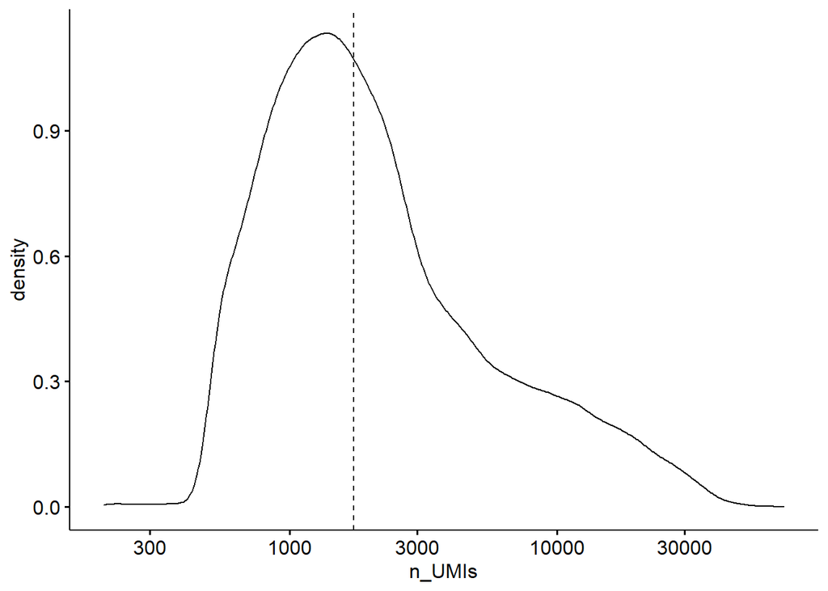

```r
ggdensity(data = umis, x = "n_UMIs", add = "median", xscale = "log10")
```

We load the provided metadata with cell annotation information

```r
# MetaData
meta <- read.table("data/MetaData.txt", header = T, sep = "\t")
meta$cell <- as.character(meta$cell)
summary(as.factor(meta$CellType))
```

```
## Alveolar   B_cell       EC      Epi    Fibro  Myeloid   T_cell    tumor
##     1710     5603     1592      214     1465     9756    24911     7447
```

We merge the total UMI counts per cell and Z-scale normalize within each individual patient piece.

```r
meta <- merge(meta, umis, by = "cell")

meta$piece_source <- gsub(pattern = "[0-9]_", replacement = "", x = meta$Patient_piece)

meta$z_UMI_all <- ave(log10(meta$n_UMIs), meta$Patient_piece, FUN = scale)
```

In each tumor piece and cell group, we want to normalize each cell types RNA output to each other cell type within the tumor. We create a summary of the number of cells per group, and the total and mean UMI counts.

```r
# Create piecewise summary
piece.summary <- meta %>%
  group_by(PatientNumber.MS, Patient_piece, piece_source) %>%
  summarise(piece_cell_count = n(), piece_umis = sum(n_UMIs), sample_mean_umi = mean(n_UMIs))

# Create cell type summary
cell.type.summary <- filter(meta, CellFromTumor == T) %>%
  group_by(PatientNumber.MS, Patient_piece, CellType) %>%
  summarise(celltype_count = n(), celltype_umis = sum(n_UMIs), celltype_mean_umis = mean(n_UMIs))

# And merge the two
cell.type.summary <- merge(piece.summary, cell.type.summary, by = c("PatientNumber.MS", "Patient_piece"))
```

Then we calculate the proportion of each cell type within each ‘piece’ amd the proportion of UMIs. Also, for an RNAmp-like comparison, we measure the relative contribution of each cell type to the overall RNA output as a fold change.

```r
# Compute cell type proportions and umi proportions and mean umis per cell
cell.type.summary <- cell.type.summary %>%
  mutate(
    cell_prop = celltype_count / piece_cell_count,
    UMI_prop = celltype_umis / piece_umis
  )
# Nice labels
cell.type.summary$prop.labs <- paste0(cell.type.summary$CellType, " (", (round(cell.type.summary$cell_prop, digits = 2) * 100), "%)")
cell.type.summary$umi.labs <- paste0(cell.type.summary$CellType, " (", (round(cell.type.summary$UMI_prop, digits = 2) * 100), "%)")

# Global amp -- take the average UMIs of the cell type vs the UMIs of all other cell types
cell.type.summary$vs.others <- with(cell.type.summary, (celltype_umis / celltype_count) / ((piece_umis - celltype_umis) / (piece_cell_count - celltype_count)))

# Within population shift (percentage -- we don't use this)
cell.type.summary$prop_change <- with(cell.type.summary, UMI_prop / cell_prop)
cell.type.summary$piece_source <- factor(cell.type.summary$piece_source, levels = c("core", "middle", "edge"))
```

And plot the result, showing that tumor cell’s RNA output is significantly increased compared to each other cell type.

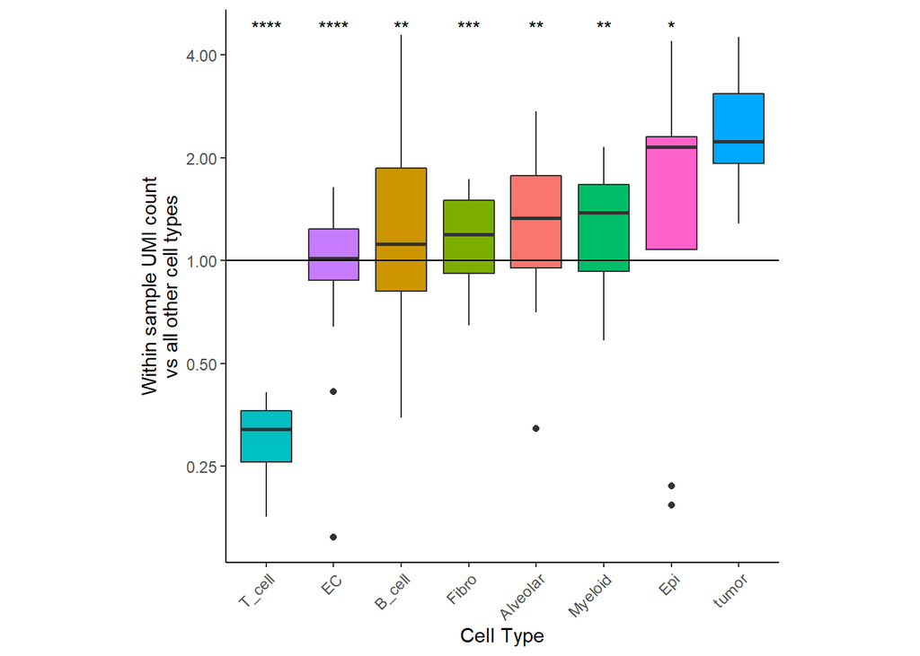

```r
# Consistent cell type colorings
celltype_cols <- vector(length = length(unique(cell.type.summary$CellType)))
gg_color_hue <- function(n) {
  hues <- seq(15, 375, length = n + 1)
  hcl(h = hues, l = 65, c = 100)[1:n]
}
celltype_cols <- gg_color_hue(length(unique(cell.type.summary$CellType)))
names(celltype_cols) <- as.vector(unique(cell.type.summary$CellType))

# Plot of amp value versus all other cells -- this is like a populatino level summary
ggplot(cell.type.summary, aes(x = reorder(CellType, vs.others, median), y = vs.others)) +
  geom_boxplot(aes(fill = CellType)) +
  scale_y_continuous(trans = "log2", breaks = 2^(-5:5)) +
  geom_hline(yintercept = 1) +
  theme_classic() +
  theme(aspect.ratio = 1, axis.text.x = element_text(angle = 45, vjust = 1, hjust = 1), legend.position = "none") +
  labs(y = "Within sample UMI count\nvs all other cell types", x = "Cell Type") +
  scale_fill_manual(values = celltype_cols) +
  stat_compare_means(ref.group = "tumor", label = "p.signif", method = "t.test", method.args = list(pool.sd = T))
```

The TCGA average fold change in RNA output is almost identical to single-cell derived values

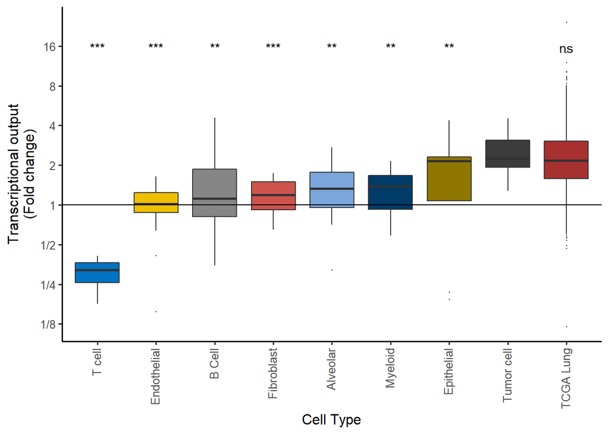

```r
# Load TCGA RNAmp data
tcga.amp <- read.table(file = "data/Supplemental Table 2.txt", header = T, sep = "\t")
# Do this but with TCGA data on the right
tcga.lung.dat <- filter(tcga.amp, project_code %in% c("LUAD", "LUSC")) %>% dplyr::select(project_code, rna_output_fch, sample_name)

tcga.lung.dat$CellType <- "TCGA_Lung"
tcga.lung.dat$vs.others <- tcga.lung.dat$rna_output_fch

celltype.tcga.df <- rbind(tcga.lung.dat[, c("CellType", "vs.others")], cell.type.summary[, c("CellType", "vs.others")])

# Reorder by median, but TCGA tumors on the left
celltype.tcga.df$CellType <- factor(celltype.tcga.df$CellType, levels = c("T_cell", "EC", "B_cell", "Fibro", "Alveolar", "Myeloid", "Epi", "tumor", "TCGA_Lung"), labels = c("T cell", "Endothelial", "B Cell", "Fibroblast", "Alveolar", "Myeloid", "Epithelial", "Tumor cell", "TCGA Lung"))

ggplot(celltype.tcga.df, aes(x = CellType, y = vs.others)) +
  geom_boxplot(aes(fill = CellType), outlier.size = 0.2) +
  scale_y_continuous(trans = "log2", breaks = 2^(-3:4), labels = c("1/8", "1/4", "1/2", 1, 2, 4, 8, 16)) +
  geom_hline(yintercept = 1) +
  theme_classic(base_size = 12) +
  theme(axis.text.x = element_text(angle = 90, vjust = 0.35, hjust = 1), legend.position = "none") +
  labs(y = "Transcriptional output\n(Fold change)", x = "Cell Type") +
  scale_fill_jco() +
  stat_compare_means(ref.group = "Tumor cell", label = "p.signif", symnum.args = list(cutpoints = c(0, 0.001, 0.01, 0.05, 1), symbols = c("***", "**", "*", "ns")), method = "t.test", method.args = list(pool.sd = T), label.y.npc = 0.9)
```

```r
celltype.tcga.df %>%
  group_by(CellType) %>%
  summarise(mean = mean(vs.others), median = median(vs.others))
```

| CellType | mean | median |
| --- | --- | --- |
| T cell | 0.302351 | 0.3212539 |
| Endothelial | 1.002872 | 1.0157194 |
| B Cell | 1.648147 | 1.1166721 |
| Fibroblast | 1.191829 | 1.1930486 |
| Alveolar | 1.410746 | 1.3292899 |
| Myeloid | 1.375968 | 1.3816922 |
| Epithelial | 1.874510 | 2.1470730 |
| Tumor cell | 2.570714 | 2.2313558 |
| TCGA Lung | 2.587721 | 2.1700000 |

Let’s graph the individual tumor pieces from each patient to see the trend across all sequenced tumor pieces.

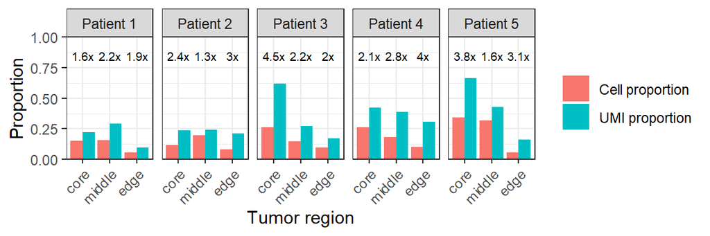

```r
cell.type.summary.melt <- reshape2::melt(cell.type.summary, id.vars = c("PatientNumber.MS", "Patient_piece", "piece_cell_count", "piece_umis", "piece_source", "sample_mean_umi", "CellType", "vs.others"), measure.vars = c("cell_prop", "UMI_prop"))

cell.type.summary.melt$variable <- factor(cell.type.summary.melt$variable, labels = c("Cell proportion", "UMI proportion"))

cell.type.summary.melt$patient <- with(cell.type.summary.melt, paste0("Patient ", PatientNumber.MS))
cell.type.summary$patient <- with(cell.type.summary, paste0("Patient ", PatientNumber.MS))

# Annotate  above with the fold change
ggplot(filter(cell.type.summary.melt, CellType == "tumor"), aes(x = piece_source, y = value, fill = variable)) +
  geom_col(position = "dodge") +
  facet_grid(. ~ patient) +
  labs(x = "Tumor region", y = "Proportion", fill = NULL) +
  theme_bw() +
  theme(axis.text.x = element_text(angle = 45, hjust = 1, vjust = 1)) +
  scale_y_continuous(limits = c(0, 1), expand = c(0, 0)) +
  geom_text(data = unique(filter(cell.type.summary.melt, CellType == "tumor", variable == "UMI proportion")), aes(label = paste0(round(vs.others, 1), "x")), y = 0.85, size = 2.5)
```

The change in RNA output can also be visualized as a Sankey (or alluvial) plot

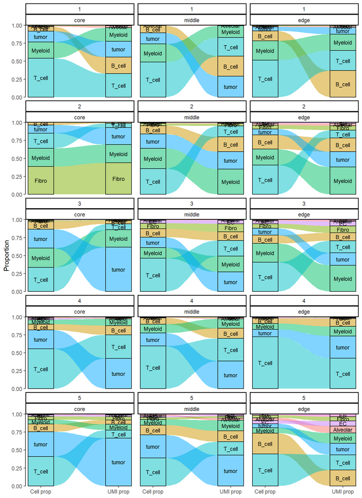

```r
dat.allu <- reshape2::melt(cell.type.summary, id.vars = c("Patient_piece", "PatientNumber.MS", "piece_source", "CellType", "vs.others"), measure.vars = c("cell_prop", "UMI_prop"))

dat.allu$variable <- factor(dat.allu$variable, labels = c("Cell prop", "UMI prop"))
tumor.vs <- round(dat.allu[dat.allu$CellType == "tumor" & dat.allu$variable == "Cell prop", "vs.others"], 2)

ggplot(dat.allu, aes(x = variable, y = value, stratum = CellType, alluvium = CellType, fill = CellType, label = CellType)) +
  scale_y_continuous(expand = c(0, 0)) +
  scale_x_discrete(expand = c(0.1, 0.1)) +
  geom_flow(decreasing = T) +
  geom_stratum(alpha = 0.5, decreasing = T) +
  geom_text(stat = "stratum", size = 3, decreasing = T) +
  theme_classic() +
  theme(legend.position = "none", axis.line.x = element_blank(), plot.title = element_text(hjust = 0.5)) +
  labs(x = NULL, y = "Proportion") +
  scale_fill_manual(values = celltype_cols) +
  facet_wrap(PatientNumber.MS ~ piece_source, nrow = 5, ncol = 3)
```

## 1.2 Intra-tumor heterogeneity in RNA output

In the next section of the analysis, we focus only on the tumor cell populations, looking to explore if different tumor cell populations exhibit differences in RNA output.

Perform clustering on the tumor cell data using Seurat scTransform. First we extract the cells of interest (tumor cells)

```r
tumor.cells <- merge(meta, cell.type.summary) %>% filter(CellType == "tumor", CellFromTumor == "TRUE") # We have fewer tumor cells than the above calc b/c of those within normal samples which we exclude

# Subset only for identified tumor cells
tumor.lung.counts <- RawDataLung.table.rds[, which(colnames(RawDataLung.table.rds) %in% tumor.cells$cell)]

tumor.lung.counts.meta <- tumor.cells
rownames(tumor.lung.counts.meta) <- tumor.lung.counts.meta$cell
```

And then perform normalization and clustering

```r
# Create Seurat object
lung <- CreateSeuratObject(counts = tumor.lung.counts, meta.data = tumor.lung.counts.meta)

# store mitochondrial percentage in object meta data
lung <- PercentageFeatureSet(object = lung, pattern = "^MT-", col.name = "percent.mt")

# run sctransform
lung <- SCTransform(object = lung, vars.to.regress = "percent.mt", verbose = T, return.only.var.genes = FALSE)

# These are now standard steps in the Seurat workflow for visualization and clustering
lung <- RunPCA(object = lung, verbose = T)

# Run UMAP
lung <- RunUMAP(object = lung, dims = 1:30, verbose = T)

lung <- FindNeighbors(object = lung, dims = 1:30, verbose = T)
lung <- FindClusters(object = lung, verbose = T)

save(lung, file = "data/lung.rda") # save for easy loading
```

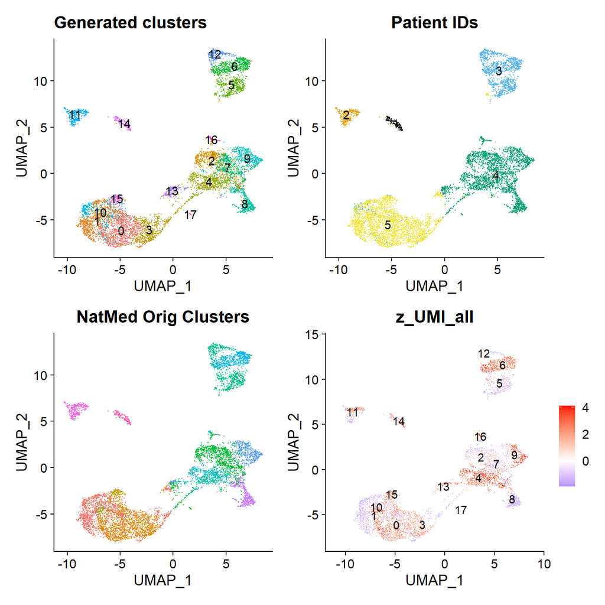

```r
# Number of clusters
n.clust <- length(unique(lung[[]]$seurat_clusters))

# Base UMAP plot
cluster.umap <- DimPlot(object = lung, label = TRUE, cols = gg_color_hue(n.clust)) + theme(aspect.ratio = 1) + NoLegend() + ggtitle("Generated clusters")

# Get mapping of cluster labels
cluster.labs <- ggplot_build(cluster.umap)$data[[2]]

# Plot by patient
patient.umap <- DimPlot(object = lung, group.by = "PatientNumber.MS", label = T) + theme(aspect.ratio = 1) + scale_color_colorblind() + labs(color = "Patient") + NoLegend() + ggtitle("Patient IDs")

# Original NatMed paper's clusters
orig.cluster.umap <- DimPlot(object = lung, group.by = "cluster", label = F, repel = T) + theme(aspect.ratio = 1) + NoLegend() + ggtitle("NatMed Orig Clusters")

zUMI.plot <- FeaturePlot(object = lung, features = "z_UMI_all", order = T, label = F, pt.size = 0.01) + theme(aspect.ratio = 1) + geom_text(data = cluster.labs, aes(x = x, y = y, label = label)) + scale_color_gradient2(low = "blue", mid = "white", high = "red")

# Plot together
cluster.umap + patient.umap + orig.cluster.umap + zUMI.plot
```

zUMIs are not distributed evenly between clusters.

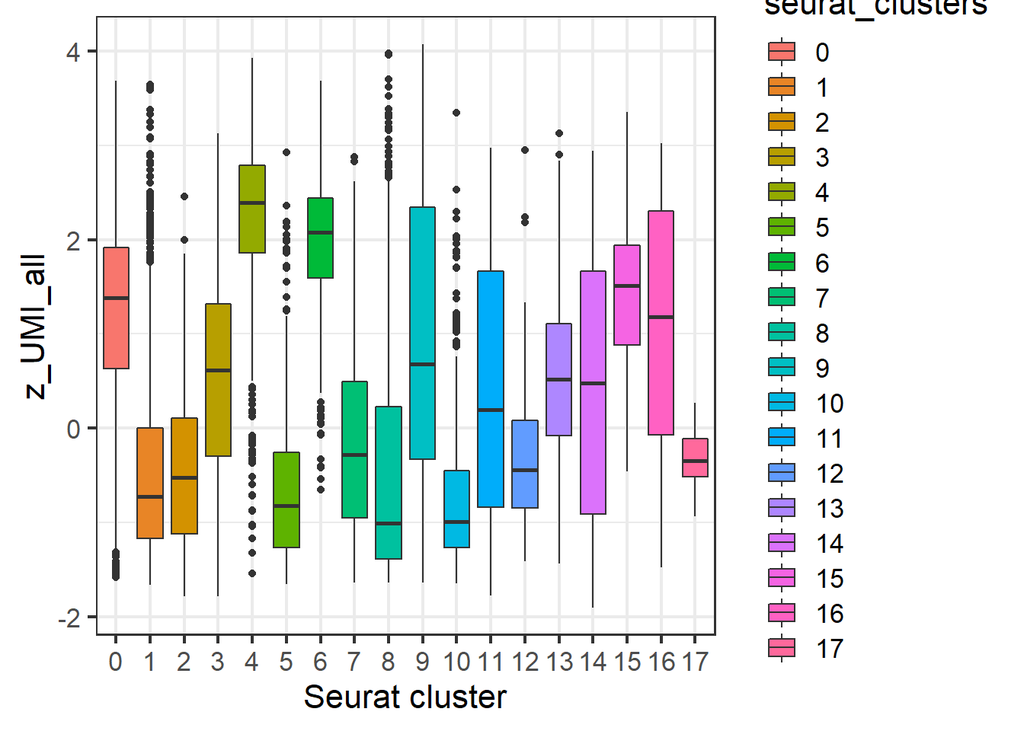

```r
zumi.per.clust <- ggplot(lung[[]], aes(x = seurat_clusters, y = z_UMI_all)) +
  geom_boxplot(aes(fill = seurat_clusters)) +
  labs(x = "Seurat cluster") +
  theme(aspect.ratio = 1) +
  scale_fill_manual(values = gg_color_hue(n.clust))
zumi.per.clust
```

Recreate the alluvial plots this time just with tumor cell clusters.

```r
# Need to load the lung seruat object for the following:
dat <- lung[[]]
tumor.dat <- merge(tumor.cells, dat[, c("cell", "seurat_clusters")])
rm(dat)

# Create piecewise summary
tumor_piece.summary <- tumor.dat %>%
  group_by(PatientNumber.MS, Patient_piece, piece_source) %>%
  summarise(piece_cell_count = n(), piece_umis = sum(n_UMIs), sample_mean_umi = mean(n_UMIs))

# Create seurat cluster type summary
tumor_clone.type.summary <- filter(tumor.dat) %>%
  group_by(PatientNumber.MS, Patient_piece, seurat_clusters) %>%
  summarise(celltype_count = n(), celltype_umis = sum(n_UMIs), celltype_mean_umis = mean(n_UMIs)) %>%
  data.frame()

# Merge the two
tumor_cell.type.summary <- merge(tumor_piece.summary, tumor_clone.type.summary, by = c("PatientNumber.MS", "Patient_piece"))

# Compute cell type proportions and umi proportions and mean umis per cell
tumor_cell.type.summary <- tumor_cell.type.summary %>%
  mutate(
    cell_prop = celltype_count / piece_cell_count,
    UMI_prop = celltype_umis / piece_umis
  )

# Nice labels
tumor_cell.type.summary$prop.labs <- paste0(tumor_cell.type.summary$seurat_clusters, " (", (round(tumor_cell.type.summary$cell_prop, digits = 2) * 100), "%)")
tumor_cell.type.summary$umi.labs <- paste0(tumor_cell.type.summary$seurat_clusters, " (", (round(tumor_cell.type.summary$UMI_prop, digits = 2) * 100), "%)")

# Global amp -- take the average UMIs of the cell type vs the UMIs of all other cell types
tumor_cell.type.summary$vs.others <- with(tumor_cell.type.summary, (celltype_umis / celltype_count) / ((piece_umis - celltype_umis) / (piece_cell_count - celltype_count)))

# Within population shift (percentage)
tumor_cell.type.summary$prop_change <- with(tumor_cell.type.summary, UMI_prop / cell_prop)

tumor_cell.type.summary$piece_source <- factor(tumor_cell.type.summary$piece_source, levels = c("core", "middle", "edge"))

# Consistent cell type colorings
s_cols <- vector(length = length(unique(tumor_cell.type.summary$seurat_clusters)))

gg_color_hue <- function(n) {
  hues <- seq(15, 375, length = n + 1)
  hcl(h = hues, l = 65, c = 100)[1:n]
}
s_cols <- gg_color_hue(length(unique(tumor_cell.type.summary$seurat_clusters)))
names(s_cols) <- as.vector(unique(tumor_cell.type.summary$seurat_clusters))

# Initialize clone plots list to store the results
clone.plots <- vector(mode = "list")
# Loop through each piece
for (i in 1:length(unique(tumor_cell.type.summary$Patient_piece))) {
  piece <- as.character(unique(tumor_cell.type.summary$Patient_piece))[[i]]
  piece.lab <- paste0("p_", as.character(unique(tumor_cell.type.summary$Patient_piece))[[i]])

  dat <- filter(tumor_cell.type.summary, Patient_piece == piece)

  # Try with ggalluvial
  dat.allu <- reshape2::melt(dat, id.vars = c("seurat_clusters", "vs.others"), measure.vars = c("cell_prop", "UMI_prop"))

  dat.allu$variable <- factor(dat.allu$variable, labels = c("Cell prop", "UMI prop"))

  allu.plot <- ggplot(dat.allu, aes(x = variable, y = value, stratum = seurat_clusters, alluvium = seurat_clusters, fill = seurat_clusters, label = seurat_clusters)) +
    scale_y_continuous(expand = c(0, 0)) +
    scale_x_discrete(expand = c(0.1, 0.1)) +
    geom_flow(decreasing = T) +
    geom_stratum(alpha = 0.5, decreasing = T) +
    geom_text(stat = "stratum", size = 3, decreasing = T) +
    theme_classic() +
    theme(legend.position = "none", axis.line.x = element_blank(), plot.title = element_text(hjust = 0.5)) +
    labs(x = NULL, y = "Proportion", title = paste0("Piece: ", piece)) +
    scale_fill_manual(values = s_cols)

  clone.plots[[piece.lab]] <- allu.plot
}

# Plot results
aspect <- 2 / 3
p3 <- with(clone.plots, p_3_core + p_3_middle + p_3_edge) & theme(aspect.ratio = aspect)
p4 <- with(clone.plots, p_4_core + p_4_middle + p_4_edge) & theme(aspect.ratio = aspect)
p5 <- with(clone.plots, p_5_core + p_5_middle + p_5_edge) & theme(aspect.ratio = aspect)
```

Plotting the individual clusters in each tumor piece demonstrates that there exists transcriptionally dominant clones, responsible for proportionally more of the tumor derived RNA than other sub-clones (even when existing as minor populations).

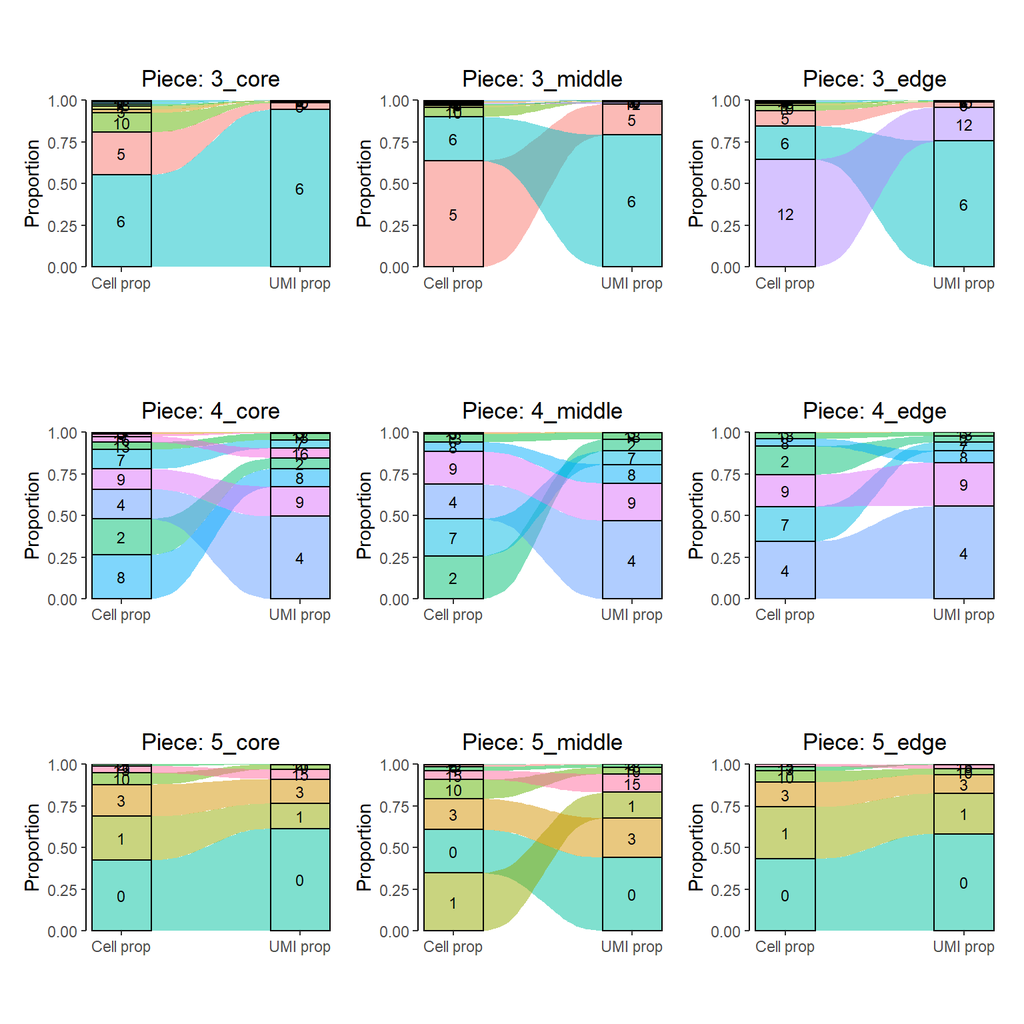

```r
p3 / p4 / p5
```